# Chapters 6 & 7 Exercises — Bayes Rules!

Worked solutions for the Lecture 4 suggested exercises: 6.2, 6.3, 6.8, 7.4, 7.9

Author

Johnny van Doorn

Published

June 12, 2026

These solutions accompany **Lecture 4 (Obtaining the Posterior: Grid Approximation & MCMC)**. They cover the suggested exercises from *Bayes Rules!* Chapter 6 (approximating the posterior) and Chapter 7 (MCMC under the hood). The exercise prompts are quoted from the book; the worked solutions, code, and figures are our own.

Remember the exam scope: you do **not** need to implement samplers by hand or use Stan, but you should understand the intuition and be able to read and interpret the diagnostics shown below.

# Chapter 6: Approximating the Posterior

## Exercise 6.2 (Trace plot diagnostics)

> For each MCMC simulation scenario described below, sketch by hand what a single chain trace plot might look like for each simulation.
> 1. The chain is mixing too slowly.
> 2. The chain has high correlation.
> 3. The chain has a tendency to get “stuck.”
> 4. The chain has no problems!

**Solution.** A trace plot shows the chain value $\theta^{(t)}$ on the $y$-axis against the iteration $t$ on the $x$-axis. Rather than sketch by hand, we simulate four chains that each exhibit one of these behaviours. The healthy chain (d) is the benchmark, the so-called “hairy caterpillar.”

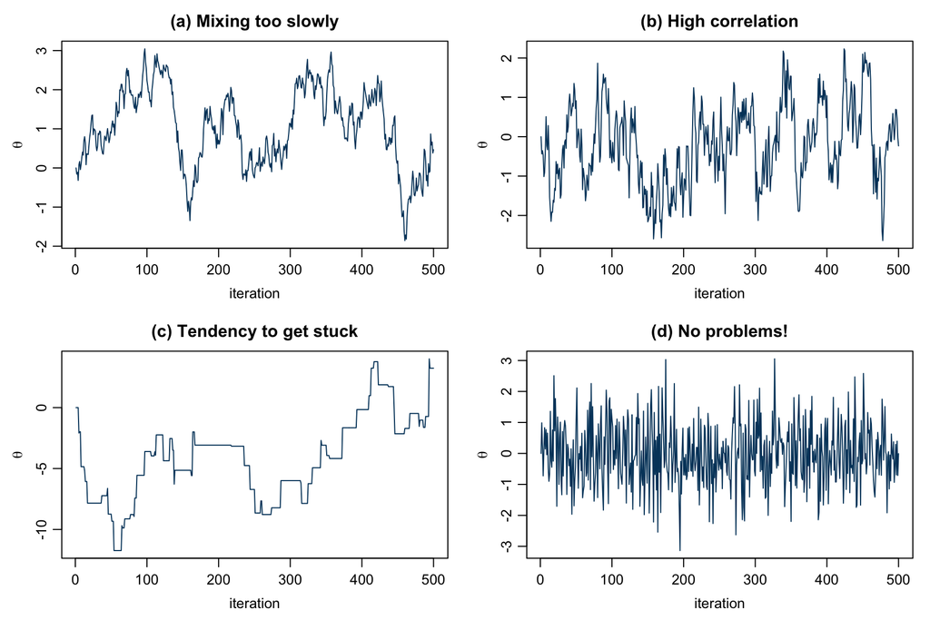

```r
set.seed(1)
N <- 500

# helper: simulate an AR(1) chain  x_t = phi * x_{t-1} + noise
ar1 <- function(N, phi, sd = 1) {
  x <- numeric(N)
  for (i in 2:N) x[i] <- phi * x[i - 1] + rnorm(1, 0, sd)
  x
}

# (a) mixing too slowly: extremely persistent -> long, slow waves that
#     have not explored the whole space within N iterations
slow <- ar1(N, phi = 0.995, sd = 0.25)

# (b) high correlation: stationary but very smooth, "snake-like"
hicorr <- ar1(N, phi = 0.9, sd = 0.5)

# (c) gets stuck: random-walk proposals accepted only ~12% of the time,
#     so the chain holds the same value for long stretches
stuck <- numeric(N)
for (i in 2:N) {
  prop <- stuck[i - 1] + rnorm(1, 0, 1.5)
  stuck[i] <- if (runif(1) < 0.12) prop else stuck[i - 1]
}

# (d) no problems: near-independent draws -> dense "hairy caterpillar"
healthy <- ar1(N, phi = 0.05, sd = 1)

par(mfrow = c(2, 2), mar = c(3.6, 3.6, 2.4, 1), mgp = c(2.1, 0.7, 0))
plot(slow,    type = "l", col = "#01426A", main = "(a) Mixing too slowly",
     xlab = "iteration", ylab = expression(theta))
plot(hicorr,  type = "l", col = "#01426A", main = "(b) High correlation",
     xlab = "iteration", ylab = expression(theta))
plot(stuck,   type = "l", col = "#01426A", main = "(c) Tendency to get stuck",
     xlab = "iteration", ylab = expression(theta))
plot(healthy, type = "l", col = "#01426A", main = "(d) No problems!",
     xlab = "iteration", ylab = expression(theta))
```

- **(a) Mixing too slowly:** the trace drifts in long, slow waves and takes many iterations to wander from one part of the space to another. It looks like a meandering river rather than rapid back-and-forth.
- **(b) High correlation:** consecutive values are nearly identical, giving a smooth, “snake-like” line. Neighbouring draws carry almost no new information.
- **(c) Gets stuck:** the trace shows flat horizontal plateaus where the chain rejected many proposals and stayed put, interrupted by occasional jumps.
- **(d) No problems!** A dense, fuzzy band oscillating rapidly around a stable level, with no trends and no flat spots: the “hairy caterpillar” we hope to see.

## Exercise 6.3 (MCMC woes)

> For each MCMC simulation scenario described below, describe how the scenario could impact the posterior approximation.
> 1. The chain is mixing too slowly.
> 2. The chain has high correlation.
> 3. The chain has a tendency to get “stuck.”

**Solution.**

**(a) Mixing too slowly.** Within a fixed number of iterations the chain has not visited the whole posterior, so the approximation is *incomplete and biased*: regions the chain has not reached yet are under-represented. Posterior summaries (mean, credible intervals, tail probabilities) computed from such a chain are unreliable, and we would need a far longer run (or a better sampler) before trusting them.

**(b) High correlation.** Strongly autocorrelated draws contain a lot of redundant information, so the **effective sample size** is much smaller than the nominal number of iterations $N$. The Monte Carlo error on any posterior estimate is therefore larger than $N$ would suggest. Our summaries are noisier and less precise. Running the chain longer (or thinning) is needed to recover precision.

**(c) Gets stuck.** A chain that lingers too long at particular values *over-represents* that region and *under-explores* the rest of the posterior. If it gets stuck at an unrepresentative value, the approximation is biased and posterior summaries are skewed toward wherever the chain stalled. Sticking is often a symptom of a poorly tuned proposal (steps too large) or of multimodality.

In all three cases the underlying issue is the same: the simulated draws are **not yet a representative sample** from the posterior, so estimates based on them cannot be trusted until the diagnostics look healthy.

## Exercise 6.8 (The Curse of Dimensionality)

> As we note in this chapter, grid approximation suffers from the curse of dimensionality.
> 1. Describe a situation in which we would want to have inference for multiple parameters (i.e., high-dimensional Bayesian models).
> 2. In your own words, explain how dimensionality can affect grid approximation and why this is a curse.

**Solution.**

**(a) A multi-parameter situation.** Almost any realistic model has more than one unknown. For example, in a **Normal model** where *neither* the mean $\mu$ *nor* the standard deviation $\sigma$ is known, we already need joint inference for two parameters $(\mu, \sigma)$. A **regression** of, say, exam score on hours studied *and* test anxiety has four unknowns: an intercept, two slopes, and the residual standard deviation $(\beta_0, \beta_1, \beta_2, \sigma)$. **Hierarchical models** (e.g., a separate ability parameter for each of many participants) can have dozens or hundreds of parameters. In all of these we want the *joint* posterior over every parameter at once.

**(b) Why dimensionality is a curse.** Grid approximation evaluates the (unnormalised) posterior at every point of a grid that spans each parameter’s range. If we use $K$ grid points per parameter and have $p$ parameters, the grid contains $K^p$ points; the cost grows **exponentially** in the number of parameters. Even with a modest $K = 100$:

```r
K <- 100
data.frame(
  parameters = c(1, 2, 3, 5, 10),
  grid_points = sprintf("%.0e", K^c(1, 2, 3, 5, 10))
)
```

| parameters | grid_points |
| --- | --- |
| 1 | 1e+02 |
| 2 | 1e+04 |
| 3 | 1e+06 |
| 5 | 1e+10 |
| 10 | 1e+20 |

With ten parameters we already need $100^{10} = 10^{20}$ evaluations, utterly infeasible. Worse, in high dimensions almost all of those grid points fall in regions of negligible posterior density, so the effort is largely wasted. This exponential blow-up is the “curse,” and it is exactly why we turn to **MCMC**, whose cost scales far more gently with dimension because it spends its time where the posterior mass actually is.

# Chapter 7: MCMC Under the Hood

## Exercise 7.4 (Tuning the Metropolis-Hastings)

> In this exercise you will consider how to tune a Uniform proposal model with half-width $w$ for a Metropolis-Hastings algorithm.
> 1. Draw a trace plot for a tour where the Uniform proposal model uses a very small $w$.
> 2. Why is it problematic if $w$ is too small, and hence defines the neighborhood around the current chain value too narrowly?
> 3. Draw a trace plot for a tour where the Uniform proposal model uses a very large $w$.
> 4. Why is it problematic if $w$ is too large, and hence defines the neighborhood too widely?
> 5. Draw a trace plot for a tour where the Uniform proposal model uses a $w$ that is neither too small or too large.
> 6. Describe how you would go about finding an appropriate half-width $w$ for a Uniform proposal model.

**Solution.** We use the book’s own `one_mh_iteration()` and `mh_tour()` functions (Section 7.3), which target the Normal–Normal posterior with prior $\mu \sim N(0,1)$ and a single observation $y = 6.25$ with likelihood SD $0.75$ (so the posterior concentrates around $\mu \approx 4$). We run three 1000-step tours: a too-small $w$, a too-large $w$, and a well-tuned $w$.

```r
one_mh_iteration <- function(w, current) {
  # STEP 1: propose the next location from Unif(current - w, current + w)
  proposal <- runif(1, min = current - w, max = current + w)
  # STEP 2: decide whether to move there
  proposal_plaus <- dnorm(proposal, 0, 1) * dnorm(6.25, proposal, 0.75)
  current_plaus  <- dnorm(current, 0, 1) * dnorm(6.25, current, 0.75)
  alpha <- min(1, proposal_plaus / current_plaus)
  next_stop <- sample(c(proposal, current), size = 1, prob = c(alpha, 1 - alpha))
  data.frame(proposal, alpha, next_stop)
}

mh_tour <- function(N, w) {
  current <- 3
  mu <- rep(0, N)
  for (i in 1:N) {
    sim <- one_mh_iteration(w = w, current = current)
    mu[i] <- sim$next_stop
    current <- sim$next_stop
  }
  data.frame(iteration = 1:N, mu)
}

set.seed(84735)
tour_small <- mh_tour(N = 1000, w = 0.01)   # (a) very small w
tour_big   <- mh_tour(N = 1000, w = 100)    # (c) very large w
tour_good  <- mh_tour(N = 1000, w = 1)      # (e) well-tuned w
```

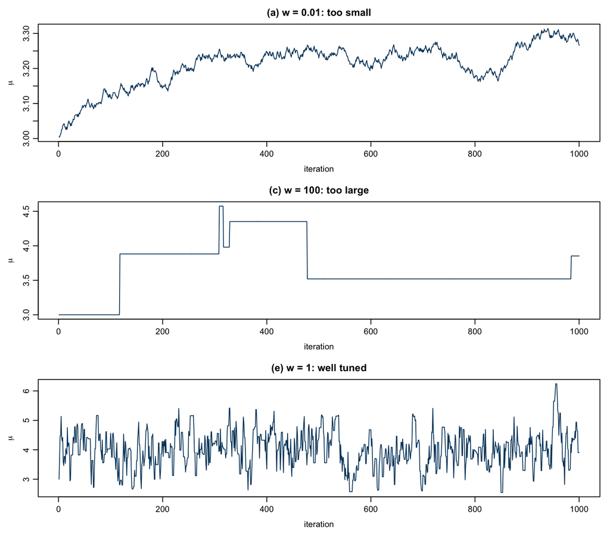

```r
par(mfrow = c(3, 1), mar = c(3.6, 3.8, 2.4, 1), mgp = c(2.2, 0.7, 0))
plot(tour_small, type = "l", col = "#01426A",
     main = "(a) w = 0.01: too small", xlab = "iteration", ylab = expression(mu))
plot(tour_big, type = "l", col = "#01426A",
     main = "(c) w = 100: too large", xlab = "iteration", ylab = expression(mu))
plot(tour_good, type = "l", col = "#01426A",
     main = "(e) w = 1: well tuned", xlab = "iteration", ylab = expression(mu))
```

**(b) Why too small $w$ is problematic.** When $w$ is tiny the proposed value is almost identical to the current one, so it is nearly always accepted, but each step is minuscule. The chain *creeps*: it explores the posterior extremely slowly, produces highly correlated draws, and may not even reach the bulk of the posterior (around $\mu \approx 4$) within the run. High acceptance, but terrible mixing and a tiny effective sample size.

**(d) Why too large $w$ is problematic.** When $w$ is huge, most proposals land far out in the tails where the posterior plausibility is minute, so the acceptance probability $\alpha$ is almost zero and the proposals are rejected. The chain therefore *stays put* for long stretches. The trace shows long flat plateaus. Again mixing is poor and the effective sample size is small, just for the opposite reason.

**(e) A well-tuned $w$** strikes a balance: proposals are far enough to make real progress but close enough to be accepted reasonably often. The trace becomes a healthy “hairy caterpillar” exploring the posterior around $\mu \approx 4$.

**(f) How to find an appropriate $w$.** Tune it empirically: run short pilot tours over a range of $w$ values and inspect (i) the **acceptance rate**, a common rule of thumb for random-walk Metropolis is to aim for roughly 0.2–0.5, avoiding both ~1 (steps too small) and ~0 (steps too large); (ii) the **trace plots**, look for the hairy caterpillar rather than a slow snake or flat plateaus; and (iii) the **effective sample size / autocorrelation**, choosing the $w$ that maximises effective samples per iteration. Exercise 7.9 makes the mechanism concrete by showing how $\alpha$ changes with $w$ for a single step.

## Exercise 7.9 (One iteration with a Uniform proposal model)

> The function `one_mh_iteration()` from the text utilizes a Uniform proposal model, $\mu' \mid \mu \sim \text{Unif}(\mu - w, \mu + w)$ with half-width $w = 1$. Starting from a current value of $\mu = 3$ and using `set.seed(1)`, run the code below and comment on the returned `proposal`, `alpha`, and `next_stop` values.
> 1. `one_mh_iteration(w = 0.01, current = 3)`
> 2. `one_mh_iteration(w = 0.5, current = 3)`
> 3. `one_mh_iteration(w = 1, current = 3)`
> 4. `one_mh_iteration(w = 3, current = 3)`

**Solution.** Using `set.seed(1)` before each call, the first `runif()` draw is the same (0.2655), so each proposal equals $3 - w + 2w(0.2655) = 3 - 0.469\,w$, i.e. a step of the *same shape* scaled by $w$. Larger $w$ therefore lands further below the current value of 3 and further from the posterior’s high-density region near $\mu \approx 4$, which is why $\alpha$ collapses as $w$ grows.

```r
for (w in c(0.01, 0.5, 1, 3)) {
  set.seed(1)
  cat(sprintf("one_mh_iteration(w = %s, current = 3):\n", w))
  print(round(one_mh_iteration(w = w, current = 3), 5))
  cat("\n")
}
```

```
one_mh_iteration(w = 0.01, current = 3):
  proposal   alpha next_stop
1  2.99531 0.98703   2.99531

one_mh_iteration(w = 0.5, current = 3):
  proposal alpha next_stop
1  2.76551 0.483         3

one_mh_iteration(w = 1, current = 3):
  proposal   alpha next_stop
1  2.53102 0.20025         3

one_mh_iteration(w = 3, current = 3):
  proposal   alpha next_stop
1  1.59305 0.00128         3
```

**Comments.**

- **(a) $w = 0.01$:** `proposal` $\approx 2.995$, essentially on top of the current value. Its plausibility is almost identical, so $\alpha \approx 0.99$ and the proposal is **accepted** (`next_stop` $\approx 2.995$). Tiny, near-certain steps, the “too small $w$” behaviour of Exercise 7.4(b).
- **(b) $w = 0.5$:** `proposal` $\approx 2.766$, a bit further from the posterior mode, giving $\alpha \approx 0.48$. Here the coin flip lands on **reject**, so `next_stop` $= 3$.
- **(c) $w = 1$:** `proposal` $\approx 2.531$, further still, so $\alpha \approx 0.20$ and the move is again **rejected** (`next_stop` $= 3$).
- **(d) $w = 3$:** `proposal` $\approx 1.593$, far out in the low-density tail, so $\alpha \approx 0.001$ and the proposal is almost surely **rejected** (`next_stop` $= 3$).

The trend is exactly the tuning story: as $w$ grows the proposals reach further from the current location, but because they move *away* from the bulk of this posterior the acceptance probability $\alpha$ falls steeply, from $\approx 0.99$ down to $\approx 0.001$. Too-small $w$ accepts everything but barely moves; too-large $w$ proposes bold jumps that are nearly always rejected. A well-chosen $w$ lives in between.

**Source:** Johnson, A. A., Ott, M. Q., & Dogucu, M. (2022). *Bayes Rules! An Introduction to Applied Bayesian Modeling.* Chapman & Hall/CRC. Exercise prompts quoted from Chapters 6–7; `one_mh_iteration()` and `mh_tour()` reproduced from Section 7.3.